# Tugas 6 dan 7 MPDW

Dinda Khamila Nurfatimah

2023-10-16

## Packages

```r
library(ggplot2)
library(tsibble)
library(tseries)
library(MASS)
library(forecast)
library(TSA)
library(TTR)
library(aTSA)
library(graphics)
```

## Import Data

Digunakan data Power Consumed yang dalam hal ini digunakan data 359 periode awal

```r
library(rio)
data <- import("https://raw.githubusercontent.com/DindaKhamila/mpdw/main/Data/DataTugas.csv")
data <- data[1:359,]
data.ts<-ts(data)
```

### Eksplorasi Data

#### Plot Data Penuh

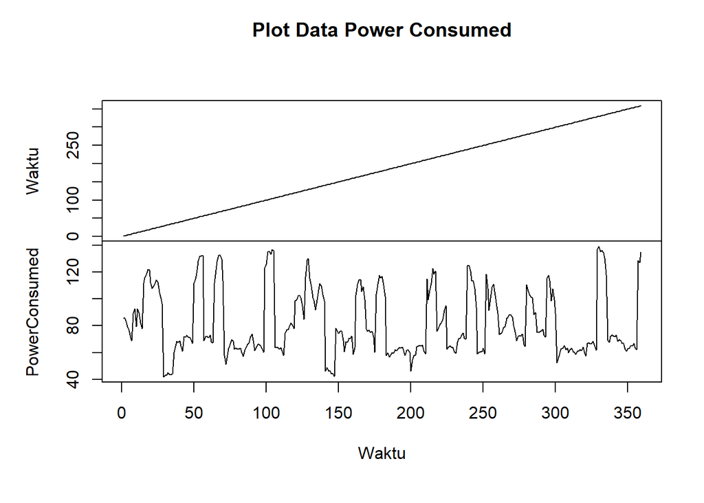

```r
plot.ts(data.ts, lty=1, xlab="Waktu", ylab="Power Consumed", main="Plot Data Power Consumed")
```

Berdasarkan plot data deret waktu, terlihat bahwa data cenderung stasioner. Berdasarkan pola data, pembagian data latih dan data uji ditetapkan dengan proporsi 85%:15%.

#### Plot Data Latih

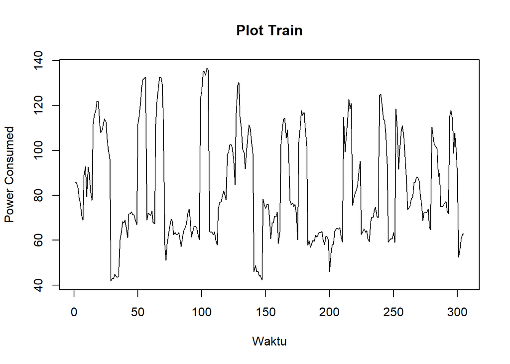

```r
train<-data$PowerConsumed[1:305]
train.ts<-ts(train)
plot.ts(train.ts, lty=1, xlab="Waktu", ylab="Power Consumed", main="Plot Train")
```

Berdasarkan plot data deret waktu pada data latih, terlihat bahwa data cenderung stasioner dalam rataan, ditandai dengan data cenderung menyebar di sekitar nilai tengahnya.

#### Plot Data Uji

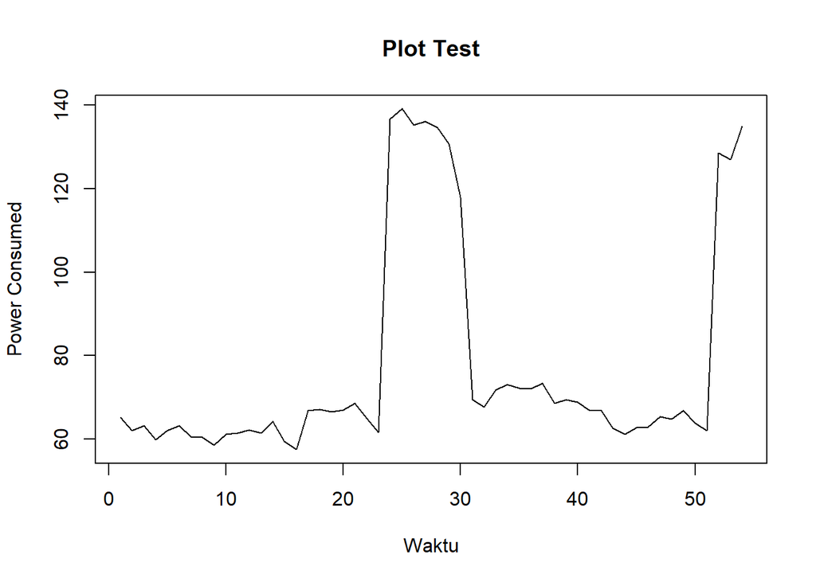

```r
test<-data$PowerConsumed[306:359]
test.ts<-ts(test)
plot.ts(test.ts, lty=1, xlab="Waktu", ylab="Power Consumed", main="Plot Test")
```

### Uji Stasioneritas Data

#### Plot ACF

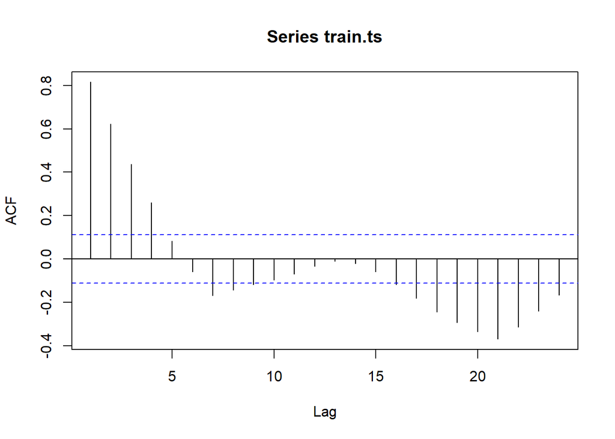

```r
acf(train.ts)
```

Berdasarkan plot ACF, terlihat bahwa plot ACF data *tails off*.

#### Uji ADF

```r
tseries::adf.test(train.ts)
```

```
##
##  Augmented Dickey-Fuller Test
##
## data:  train.ts
## Dickey-Fuller = -6.6737, Lag order = 6, p-value = 0.01
## alternative hypothesis: stationary
```

$H_0$ : Data tidak stasioner dalam rataan

$H_1$ : Data stasioner dalam rataan

Berdasarkan uji ADF tersebut, didapat *p-value* sebesar 0.01 yang lebih kecil dari taraf nyata 5% sehingga tolak $H_0$ dan menandakan bahwa data stasioner dalam rataan. Hal ini sesuai dengan hasil eksplorasi menggunakan plot time series dan plot ACF.

#### Plot Box-Cox

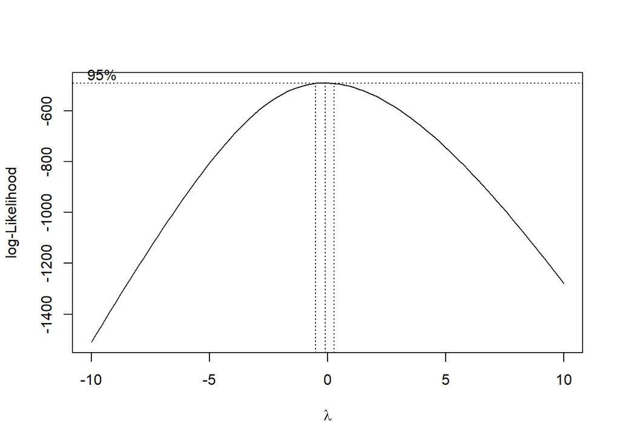

```r
index <- seq(1:305)
bc = boxcox(train.ts~index, lambda = seq(-10,10,by=1))
```

```r
#Nilai Rounded Lambda
lambda <- bc$x[which.max(bc$y)]
lambda
```

```
## [1] -0.1010101
```

```r
#SK
bc$x[bc$y > max(bc$y) - 1/2 * qchisq(.95,1)]
```

```
## [1] -0.3030303 -0.1010101  0.1010101
```

Plot Boxcox menunjukkan nilai *rounded value* ($\lambda$) optimum sebesar **-0.1010101** dan pada selang kepercayaan 95% nilai memiliki batas bawah **-0.3030303** dan batas atas **0.1010101**. Selang tersebut tidak memuat nilai satu sehingga dapat dikatakan bahwa data bangkitan tidak stasioner dalam ragam.

Dengan demikian, data stasioner dalam rataan tetapi tidak stasioner dalam ragam.

### Identifikasi Model

#### Plot ACF

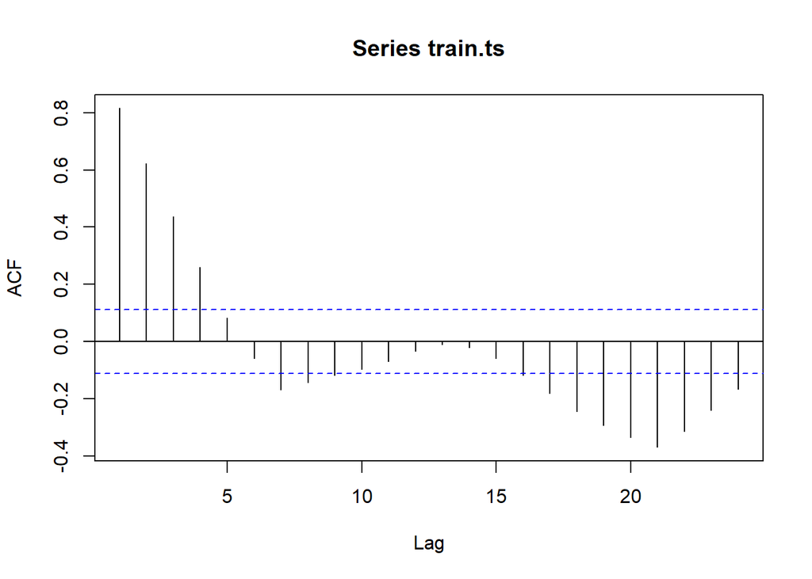

```r
acf(train.ts)
```

Berdasarkan plot tersebut, terlihat bahwa plot ACF cenderung *tails off*.

#### Plot PACF

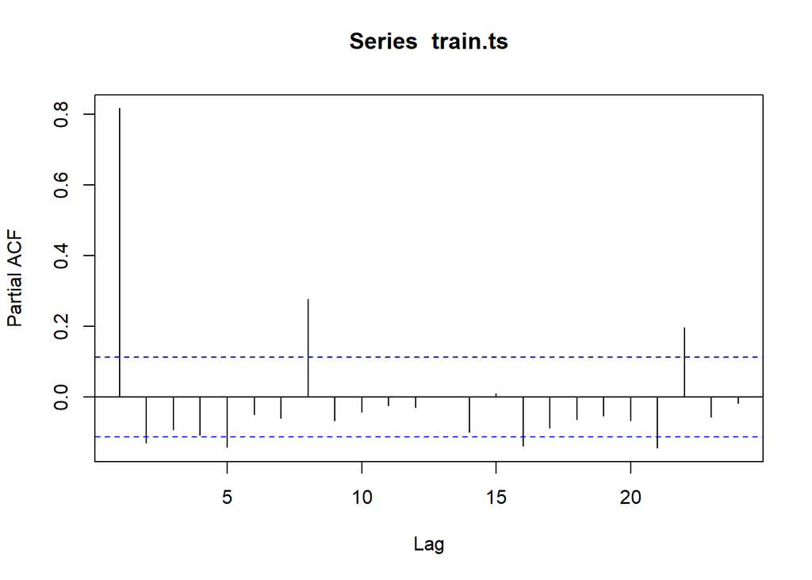

```r
pacf(train.ts)
```

Berdasarkan plot tersebut, terlihat bahwa plot PACF cenderung *cuts off* pada lag ke 1, sedangkan plot ACF dianggap *tails off*, maka model tentatifnya adalah ARIMA(1,0,0).

#### Plot EACF

```r
eacf(train.ts)
```

```
## AR/MA
##   0 1 2 3 4 5 6 7 8 9 10 11 12 13
## 0 x x x x o o x x x o o  o  o  o
## 1 x x x x o o x o o o o  o  o  o
## 2 x o o o o x x o o o o  o  o  o
## 3 x o o o o o x o o o o  o  o  o
## 4 x o x o o o x x o o o  o  o  o
## 5 x x x o o x x x o o o  o  o  o
## 6 x o x o o x x o o o o  o  o  o
## 7 x x x x x o x o o x o  o  o  o
```

Identifikasi model menggunakan plot EACF dilakukan dengan melihat ujung segitiga pada pola segitiga nol. Dalam hal ini model tentatif yang terbentuk adalah ARIMA(0,0,4), ARIMA(1,0,4), ARIMA(2,0,1), dan ARIMA(3,0,1).

### Pendugaan Parameter Model Tentatif

#### ARIMA(1,0,0)

```r
model1.da=Arima(train.ts, order=c(1,0,0),method="ML")
summary(model1.da) #AIC=2472.62
```

```
## Series: train.ts
## ARIMA(1,0,0) with non-zero mean
##
## Coefficients:
##          ar1     mean
##       0.8150  82.6492
## s.e.  0.0328   4.2039
##
## sigma^2 = 191:  log likelihood = -1233.31
## AIC=2472.62   AICc=2472.7   BIC=2483.79
##
## Training set error measures:
##                       ME     RMSE      MAE       MPE     MAPE     MASE
## Training set -0.01276346 13.77588 8.022386 -2.880305 10.17939 1.096881
##                   ACF1
## Training set 0.1081738
```

```r
lmtest::coeftest(model1.da) #semua parameter signifikan
```

```
##
## z test of coefficients:
##
##            Estimate Std. Error z value  Pr(>|z|)
## ar1        0.815001   0.032791  24.855 < 2.2e-16 ***
## intercept 82.649235   4.203853  19.660 < 2.2e-16 ***
## ---
## Signif. codes:  0 '***' 0.001 '**' 0.01 '*' 0.05 '.' 0.1 ' ' 1
```

#### ARIMA(0,0,4)

```r
model2.da=Arima(train.ts, order=c(0,0,4),method="ML")
summary(model2.da) #AIC=2481.48
```

```
## Series: train.ts
## ARIMA(0,0,4) with non-zero mean
##
## Coefficients:
##          ma1     ma2     ma3     ma4     mean
##       0.9121  0.6089  0.4328  0.2799  82.8491
## s.e.  0.0631  0.0899  0.0562  0.0764   2.5509
##
## sigma^2 = 194.7:  log likelihood = -1234.74
## AIC=2481.48   AICc=2481.76   BIC=2503.8
##
## Training set error measures:
##                       ME     RMSE      MAE       MPE     MAPE     MASE
## Training set -0.01063883 13.84018 9.028113 -3.301547 11.52937 1.234392
##                    ACF1
## Training set 0.02863148
```

```r
lmtest::coeftest(model2.da) #semua parameter signifikan
```

```
##
## z test of coefficients:
##
##            Estimate Std. Error z value  Pr(>|z|)
## ma1        0.912077   0.063084 14.4581 < 2.2e-16 ***
## ma2        0.608871   0.089893  6.7733 1.259e-11 ***
## ma3        0.432768   0.056193  7.7014 1.346e-14 ***
## ma4        0.279875   0.076413  3.6627 0.0002496 ***
## intercept 82.849116   2.550918 32.4782 < 2.2e-16 ***
## ---
## Signif. codes:  0 '***' 0.001 '**' 0.01 '*' 0.05 '.' 0.1 ' ' 1
```

#### ARIMA(1,0,4)

```r
model3.da=Arima(train.ts, order=c(1,0,4),method="ML")
summary(model3.da) #AIC=2466.33
```

```
## Series: train.ts
## ARIMA(1,0,4) with non-zero mean
##
## Coefficients:
##          ar1     ma1     ma2     ma3     ma4     mean
##       0.6055  0.2708  0.1467  0.2308  0.2253  82.8417
## s.e.  0.0834  0.0930  0.0687  0.0725  0.0740   3.6258
##
## sigma^2 = 184.6:  log likelihood = -1226.16
## AIC=2466.33   AICc=2466.7   BIC=2492.37
##
## Training set error measures:
##                       ME     RMSE      MAE       MPE     MAPE     MASE
## Training set -0.01387914 13.45126 7.958517 -2.659197 10.13714 1.088148
##                    ACF1
## Training set 0.01309702
```

```r
lmtest::coeftest(model3.da) #seluruh parameter signifikan
```

```
##
## z test of coefficients:
##
##            Estimate Std. Error z value  Pr(>|z|)
## ar1        0.605452   0.083397  7.2599 3.875e-13 ***
## ma1        0.270767   0.092989  2.9118  0.003593 **
## ma2        0.146660   0.068691  2.1351  0.032755 *
## ma3        0.230816   0.072490  3.1841  0.001452 **
## ma4        0.225322   0.074041  3.0432  0.002341 **
## intercept 82.841677   3.625771 22.8480 < 2.2e-16 ***
## ---
## Signif. codes:  0 '***' 0.001 '**' 0.01 '*' 0.05 '.' 0.1 ' ' 1
```

#### ARIMA(2,0,1)

```r
model4.da=Arima(train.ts, order=c(2,0,1),method="ML")
summary(model4.da) #AIC=2460.62
```

```
## Series: train.ts
## ARIMA(2,0,1) with non-zero mean
##
## Coefficients:
##          ar1      ar2      ma1     mean
##       1.7916  -0.8221  -0.9630  82.5113
## s.e.  0.0390   0.0332   0.0483   1.0708
##
## sigma^2 = 182.1:  log likelihood = -1225.31
## AIC=2460.62   AICc=2460.82   BIC=2479.23
##
## Training set error measures:
##                     ME     RMSE      MAE       MPE     MAPE     MASE       ACF1
## Training set 0.1473735 13.40603 8.114977 -2.460455 10.22463 1.109541 0.04800084
```

```r
lmtest::coeftest(model4.da) #seluruh parameter signifikan
```

```
##
## z test of coefficients:
##
##            Estimate Std. Error z value  Pr(>|z|)
## ar1        1.791631   0.038950  45.998 < 2.2e-16 ***
## ar2       -0.822111   0.033241 -24.732 < 2.2e-16 ***
## ma1       -0.963020   0.048348 -19.919 < 2.2e-16 ***
## intercept 82.511350   1.070784  77.057 < 2.2e-16 ***
## ---
## Signif. codes:  0 '***' 0.001 '**' 0.01 '*' 0.05 '.' 0.1 ' ' 1
```

#### ARIMA(3,0,1)

```r
model5.da=Arima(train.ts, order=c(3,0,1),method="ML")
summary(model5.da) #AIC=2469.51
```

```
## Series: train.ts
## ARIMA(3,0,1) with non-zero mean
##
## Coefficients:
##          ar1     ar2      ar3     ma1     mean
##       0.0448  0.7217  -0.1677  0.8800  82.7347
## s.e.  0.0967  0.0706   0.0567  0.0818   3.6058
##
## sigma^2 = 187.2:  log likelihood = -1228.76
## AIC=2469.51   AICc=2469.79   BIC=2491.83
##
## Training set error measures:
##                        ME     RMSE      MAE       MPE     MAPE     MASE
## Training set -0.006631013 13.56894 8.112547 -2.785098 10.35242 1.109209
##                      ACF1
## Training set -0.003671171
```

```r
lmtest::coeftest(model5.da) #terdapat parameter tidak signifikan
```

```
##
## z test of coefficients:
##
##            Estimate Std. Error z value  Pr(>|z|)
## ar1        0.044754   0.096660  0.4630  0.643364
## ar2        0.721663   0.070613 10.2200 < 2.2e-16 ***
## ar3       -0.167705   0.056725 -2.9564  0.003112 **
## ma1        0.879977   0.081784 10.7598 < 2.2e-16 ***
## intercept 82.734658   3.605802 22.9449 < 2.2e-16 ***
## ---
## Signif. codes:  0 '***' 0.001 '**' 0.01 '*' 0.05 '.' 0.1 ' ' 1
```

Berdasarkan pendugaan parameter di atas, nilai AIC terkecil (2460.62) dimiliki oleh model ARIMA(2,0,1) dan parameter model ARIMA(2,0,1) juga seluruhnya signifikan sehingga model yang dipilih adalah model ARIMA(2,0,1).

### Analisis Sisaan

Model terbaik hasil identifikasi kemudian dicek asumsi sisaannya. Sisaan model ARIMA harus memenuhi asumsi normalitas, kebebasan sisaan, dan kehomogenan ragam. Diagnostik model dilakukan secara eksplorasi dan uji formal.

#### Eksplorasi Sisaan

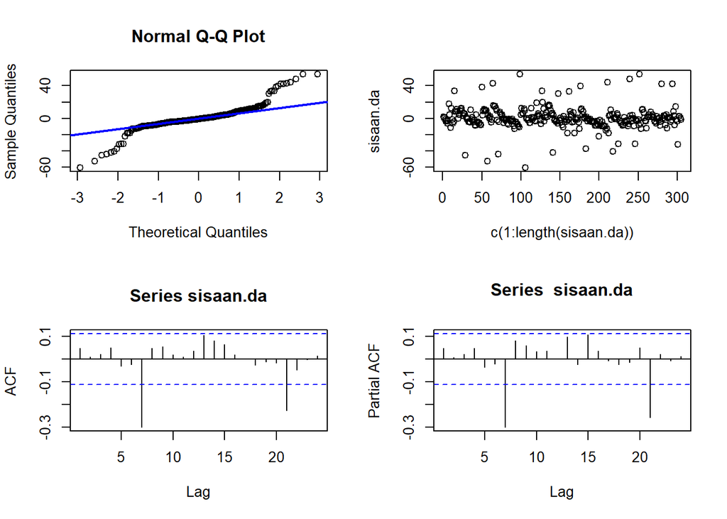

```r
#Eksplorasi
sisaan.da <- model4.da$residuals
par(mfrow=c(2,2))
qqnorm(sisaan.da)
qqline(sisaan.da, col = "blue", lwd = 2)
plot(c(1:length(sisaan.da)),sisaan.da)
acf(sisaan.da)
pacf(sisaan.da)
```

```r
par(mfrow = c(1,1))
```

Berdasarkan plot kuantil-kuantil normal, secara eksplorasi ditunjukkan sisaan tidak menyebar normal ditandai dengan titik titik yang cenderung tidak mengikuti garis $45^{\circ}$. Kemudian dapat dilihat juga lebar pita sisaan yang cenderung sama menandakan bahwa sisaan memiliki ragam yang homogen. Plot ACF dan PACF sisaan ARIMA(2,0,1) juga tidak signifikan pada beberapa lag awal yang menandakan saling bebas. Kondisi ini akan diuji lebih lanjut dengan uji formal.

#### Uji Formal

```r
#1) Sisaan Menyebar Normal
ks.test(sisaan.da,"pnorm")  #tak tolak H0 > sisaan menyebar normal
```

```
##
##  Asymptotic one-sample Kolmogorov-Smirnov test
##
## data:  sisaan.da
## D = 0.41295, p-value < 2.2e-16
## alternative hypothesis: two-sided
```

Selain dengan eksplorasi, asumsi tersebut dapat diuji menggunakan uji formal. Pada tahapan ini uji formal yang digunakan untuk normalitas adalah uji Kolmogorov-Smirnov (KS). Hipotesis pada uji KS adalah sebagai berikut.

$H_0$ : Sisaan menyebar normal

$H_1$ : Sisaan tidak menyebar normal

Berdasarkan uji KS tersebut, didapat *p-value* < 2.2e-16 yang kurang dari taraf nyata 5% sehingga tolak $H_0$ dan menandakan bahwa sisaan tidak menyebar normal. Hal ini sesuai dengan hasil eksplorasi menggunakan plot kuantil-kuantil normal.

```r
#2) Sisaan saling bebas/tidak ada autokorelasi
Box.test(sisaan.da, type = "Ljung")  #tak tolak H0 > sisaan saling bebas
```

```
##
##  Box-Ljung test
##
## data:  sisaan.da
## X-squared = 0.70968, df = 1, p-value = 0.3996
```

Selanjutnya akan dilakukan uji formal untuk kebebasan sisaan menggunakan uji Ljung-Box. Hipotesis yang digunakan adalah sebagai berikut.

$H_0$ : Sisaan saling bebas

$H_1$ : Sisaan tidak tidak saling bebas

Berdasarkan uji Ljung-Box tersebut, didapat *p-value* sebesar 0.3996 yang lebih besar dari taraf nyata 5% sehingga tak tolak $H_0$ dan menandakan bahwa sisaan saling bebas.

```r
#3) Sisaan homogen
Box.test((sisaan.da)^2, type = "Ljung")  #tak tolak H0 > sisaan homogen
```

```
##
##  Box-Ljung test
##
## data:  (sisaan.da)^2
## X-squared = 0.92317, df = 1, p-value = 0.3366
```

Hipotesis yang digunakan untuk uji kehomogenan ragam adalah sebagai berikut.

$H_0$ : Ragam sisaan homogen

$H_1$ : Ragam sisaan tidak homogen

```r
#4) Nilai tengah sisaan sama dengan nol
t.test(sisaan.da, mu = 0, conf.level = 0.95)  #tak tolak h0 > nilai tengah sisaan sama dengan 0
```

```
##
##  One Sample t-test
##
## data:  sisaan.da
## t = 0.19168, df = 304, p-value = 0.8481
## alternative hypothesis: true mean is not equal to 0
## 95 percent confidence interval:
##  -1.365552  1.660299
## sample estimates:
## mean of x
## 0.1473735
```

Terakhir, dengan uji-t, akan dicek apakah nilai tengah sisaan sama dengan nol. Hipotesis yang diujikan sebagai berikut.

$H_0$ : nilai tengah sisaan sama dengan 0

$H_1$ : nilai tengah sisaan tidak sama dengan 0

Berdasarkan uji-ttersebut, didapat *p-value* sebesar 0.8481 yang lebih besar dari taraf nyata 5% sehingga tak tolak $H_0$ dan menandakan bahwa nilai tengah sisaan sama dengan nol.

### Overfitting

Tahapan selanjutnya adalah *overfitting* dilakukan dengan menaikkan orde AR(p) dan MA(q) dari model ARIMA(2,0,1) untuk melihat apakah terdapat model lain yang lebih baik dari model saat ini. Kandidat model *overfitting* adalah ARIMA(3,0,1) dan ARIMA(2,0,2).

```r
# ARIMA(3,0,1)
model6=Arima(train.ts, order=c(3,0,1),method="ML")
summary(model6) #AIC=2469.51
```

```
## Series: train.ts
## ARIMA(3,0,1) with non-zero mean
##
## Coefficients:
##          ar1     ar2      ar3     ma1     mean
##       0.0448  0.7217  -0.1677  0.8800  82.7347
## s.e.  0.0967  0.0706   0.0567  0.0818   3.6058
##
## sigma^2 = 187.2:  log likelihood = -1228.76
## AIC=2469.51   AICc=2469.79   BIC=2491.83
##
## Training set error measures:
##                        ME     RMSE      MAE       MPE     MAPE     MASE
## Training set -0.006631013 13.56894 8.112547 -2.785098 10.35242 1.109209
##                      ACF1
## Training set -0.003671171
```

```r
lmtest::coeftest(model6) #ar1 tidak signifikan
```

```
##
## z test of coefficients:
##
##            Estimate Std. Error z value  Pr(>|z|)
## ar1        0.044754   0.096660  0.4630  0.643364
## ar2        0.721663   0.070613 10.2200 < 2.2e-16 ***
## ar3       -0.167705   0.056725 -2.9564  0.003112 **
## ma1        0.879977   0.081784 10.7598 < 2.2e-16 ***
## intercept 82.734658   3.605802 22.9449 < 2.2e-16 ***
## ---
## Signif. codes:  0 '***' 0.001 '**' 0.01 '*' 0.05 '.' 0.1 ' ' 1
```

```r
# ARIMA(2,0,2)
model7=Arima(train.ts, order=c(2,0,2),method="ML")
summary(model7) #AIC=2464.68
```

```
## Series: train.ts
## ARIMA(2,0,2) with non-zero mean
##
## Coefficients:
##          ar1      ar2      ma1     ma2     mean
##       1.6339  -0.7220  -0.7529  0.0398  82.8842
## s.e.  0.1712   0.1161   0.1703  0.1265   2.5118
##
## sigma^2 = 184.2:  log likelihood = -1226.34
## AIC=2464.68   AICc=2464.97   BIC=2487.01
##
## Training set error measures:
##                       ME     RMSE      MAE       MPE     MAPE     MASE
## Training set -0.01022206 13.46139 8.289967 -2.728177 10.59055 1.133467
##                     ACF1
## Training set 0.004727761
```

```r
lmtest::coeftest(model7) #ma2 tidak signifikan
```

```
##
## z test of coefficients:
##
##            Estimate Std. Error z value  Pr(>|z|)
## ar1        1.633869   0.171238  9.5415 < 2.2e-16 ***
## ar2       -0.721968   0.116100 -6.2185 5.019e-10 ***
## ma1       -0.752931   0.170302 -4.4211 9.818e-06 ***
## ma2        0.039799   0.126459  0.3147     0.753
## intercept 82.884177   2.511829 32.9975 < 2.2e-16 ***
## ---
## Signif. codes:  0 '***' 0.001 '**' 0.01 '*' 0.05 '.' 0.1 ' ' 1
```

Berdasarkan kedua model hasil *overfitting* di atas, model ARIMA(3,0,1) dan ARIMA(2,0,2) memiliki AIC yang lebih besar dibandingkan dengan model ARIMA(2,0,1) dan parameter kedua model ARIMA(3,0,1) dan ARIMA(2,0,2) tidak seluruhnya signifikan. Oleh karena itu, model ARIMA(2,0,1) akan tetap digunakan untuk melakukan peramalan.

### Peramalan

Peramalan dilakukan menggunakan fungsi `forecast()` . Contoh peramalan berikut ini dilakukan untuk 54 hari ke depan.

```r
#---FORECAST---#
ramalan.da <- forecast::forecast(model4.da, h = 54)
ramalan.da
```

```
##     Point Forecast    Lo 80     Hi 80    Lo 95     Hi 95
## 306       65.41258 48.11828  82.70687 38.96323  91.86192
## 307       67.91716 45.45723  90.37708 33.56767 102.26665
## 308       70.42104 45.20789  95.63420 31.86085 108.98123
## 309       72.84803 46.16134  99.53471 32.03427 113.66179
## 310       75.13782 47.72921 102.54644 33.21996 117.05569
## 311       77.24504 49.54507 104.94500 34.88160 119.60848
## 312       79.13792 51.36284 106.91301 36.65959 121.61625
## 313       80.79691 53.01945 108.57437 38.31495 123.27887
## 314       82.21303 54.41658 110.00949 39.70202 124.72404
## 315       83.38634 55.50768 111.26500 40.74960 126.02308
## 316       84.32426 56.28589 112.36263 41.44328 127.20524
## 317       85.04007 56.77215 113.30800 41.80802 128.27213
## 318       85.55148 57.00412 114.09884 41.89206 129.21090
## 319       85.87924 57.02703 114.73146 41.75359 130.00490
```

[output cut: 40 more lines]

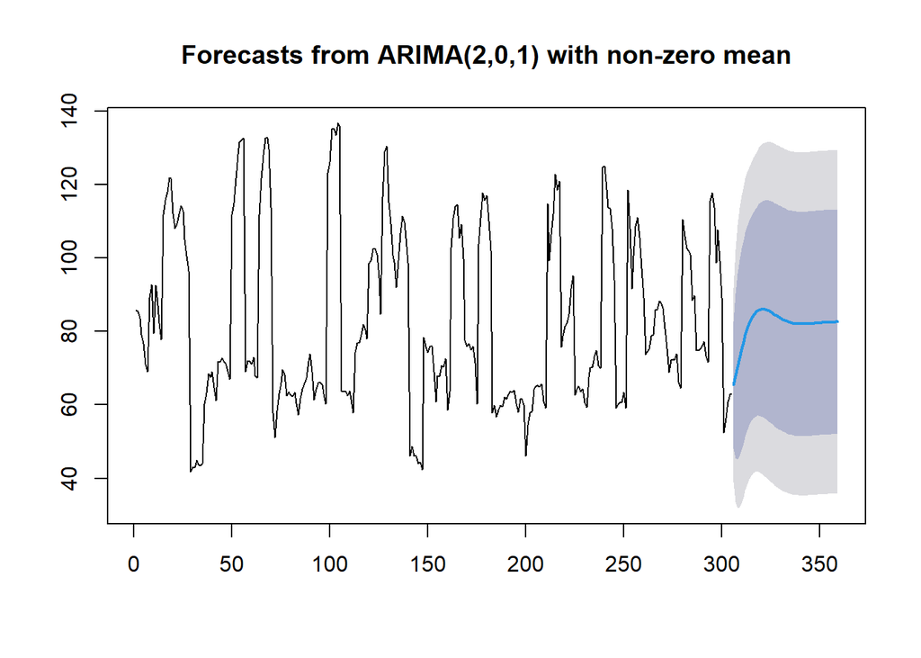

```r
data.ramalan.da <- ramalan.da$mean
plot(ramalan.da)
```

Berdasarkan hasil plot ramalan di atas, dapat dilihat bahwa ramalan ARIMA(2,0,1) cenderung stabil hingga akhir periode. Selanjutnya, dapat dicari nilai akurasi antara hasil ramalan dengan data uji sebagai berikut.

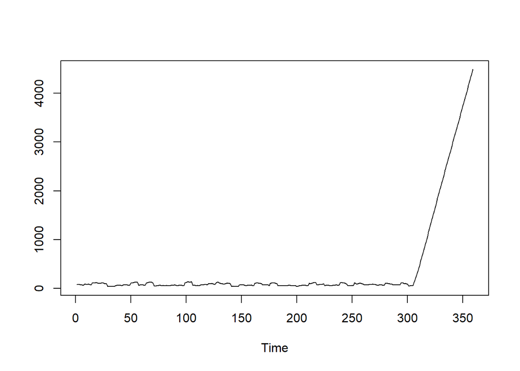

```r
pt_1 <- train.ts[305] #nilai akhir data latih
hasil.forc.Diff <- data.ramalan.da
hasil <- diffinv(hasil.forc.Diff, differences = 1) + pt_1
#has.1 sama hasilnta dengan: cumsum(c(pt_1,hasil.forc.Diff))
ts.plot(train.ts,hasil)
```

```r
perbandingan.da<-matrix(data=c(head(test.ts, n=54), hasil[-1]),
                     nrow = 54, ncol = 2)
colnames(perbandingan.da)<-c("Aktual","Hasil Forecast")
perbandingan.da
```

```
##       Aktual Hasil Forecast
##  [1,]   65.2       128.4126
##  [2,]   62.1       196.3297
##  [3,]   63.2       266.7508
##  [4,]   59.9       339.5988
##  [5,]   62.0       414.7366
##  [6,]   63.2       491.9817
##  [7,]   60.6       571.1196
##  [8,]   60.4       651.9165
##  [9,]   58.5       734.1295
## [10,]   61.2       817.5159
## [11,]   61.4       901.8401
## [12,]   62.2       986.8802
## [13,]   61.4      1072.4317
## [14,]   64.2      1158.3109
```

[output cut: 40 more lines]

```r
accuracy(ts(hasil[-1]), head(test.ts, n=54))
```

```
##                 ME     RMSE      MAE       MPE     MAPE      ACF1 Theil's U
## Test set -2213.358 2560.519 2213.358 -2975.294 2975.294 0.9466921  154.7524
```